# Индивидуальный проект

5 Этап. Использование Burp Suite

Панина Жанна Валерьевна

1132246710@rudn.ru

Российский университет дружбы народов

2026-05-10

# Информация

## Докладчик

- Панина Жанна Валерьевна
- студентка НКАбд-02-24
- Российский университет дружбы народов им. П. Лумумбы
- 1132246710@rudn.ru
- https://github.com/zvpanina/study_2025-2026_infosec-intro

# Вводная часть

## Цель работы

Научиться использовать инструмент Burp Suite.

## Теоретическое введение

Burp Suite представляет собой набор мощных инструментов безопасности веб-приложений, которые демонстрируют реальные возможности злоумышленника, проникающего в веб-приложения. Эти инструменты позволяют сканировать, анализировать и использовать веб-приложения с помощью ручных и автоматических методов. Интеграция интерфейсов этих инструментов обеспечивает полную платформу атаки для обмена информацией между одним или несколькими инструментами, что делает Burp Suite очень эффективной и простой в использовании платформой для атаки веб-приложений.

# Основная часть

Запускаю локальный сервер для дальнейшего тестирования Burp Suite.

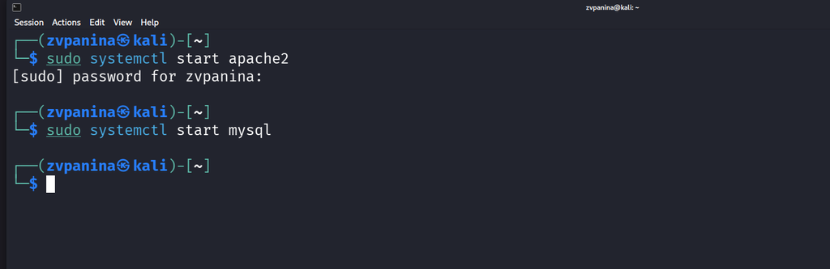

Рисунок 1: Запуск mysql и apache2

Запускаю инструмент Burp Suite.

[figure not shown]

Рисунок 2: Запуск Burp Suite

Открываю сетевые настройки браузера для подготовки к работе.

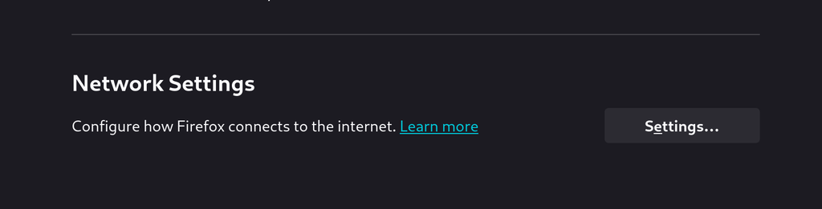

Рисунок 3: Сетевые настройки браузера

Изменяю настройки сервера для работы с прокси и захвата данных с помощью Burp Suite.

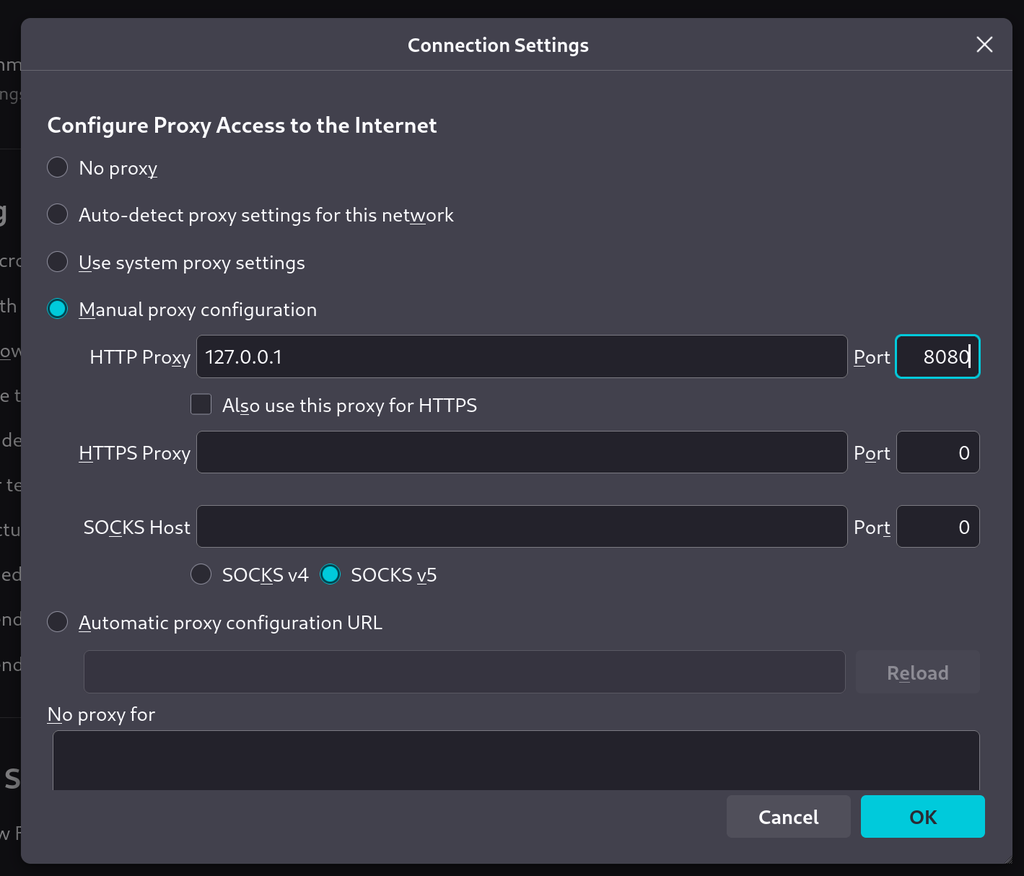

Рисунок 4: Изменение настроек

Изменяю настройки Proxy в Burp Suite для дальнейшей работы.

[figure not shown]

Рисунок 5: Изменение настроек Proxy

Во вкладке Proxy устанавливаю значение “Intercept” на “on”.

[figure not shown]

Рисунок 6: Включение Intercept

Устанавливаю параметр `network_allow_hijacking_localhost` на true, чтобы Burp Suite корректно работал с локальным сервером.

[figure not shown]

Рисунок 7: Параметр network_allow_hijacking_localhost

Пытаюсь зайти в браузере на DVWA, сразу во вкладке Proxy вижу захваченный запрос. Нажимаю “Forward” для загрузки страницы.

[figure not shown]

Рисунок 8: Захваченный запрос

Сразу загрузилась страница авторизации и поменялся текс запроса.

[figure not shown]

Рисунок 9: Страница авторизации и изменения

Можем перейти на вкладку Target, чтобы посмотреть историю запросов.

[figure not shown]

Рисунок 10: Вкладка Target

Ввожу неверные случайные данные для входа, пытаюсь залогиниться и вижу в запросе строку, в которой отображаются введённые мной данные.

[figure not shown]

Рисунок 11: Попытка входа

[figure not shown]

Переходим на вкладку Intruder, видим свой запрос и значение по умолчанию у типа атаки .

[figure not shown]

Рисунок 13: Вкладка Intruder

Изменяем значение типа атаки на Cluster Bomb attack и проставляем специальные символы у имени пользователя и пароля - эти данные и будем пробивать.

[figure not shown]

Рисунок 14: Изменение типа атаки

Составляем два списка со значениями для подбора в Payload setting - сначала первый

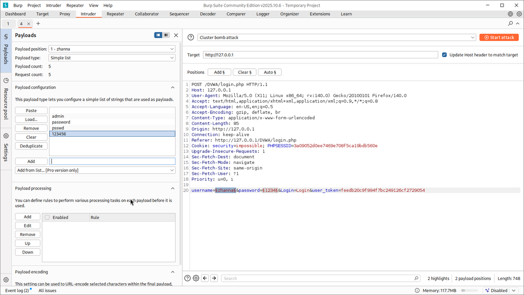

Рисунок 15: Первый список со значениями

Затем второй. В строке Request count видим число - это нужное количество запросов, чтобы проверить все возможные пары пользователь-пароль.

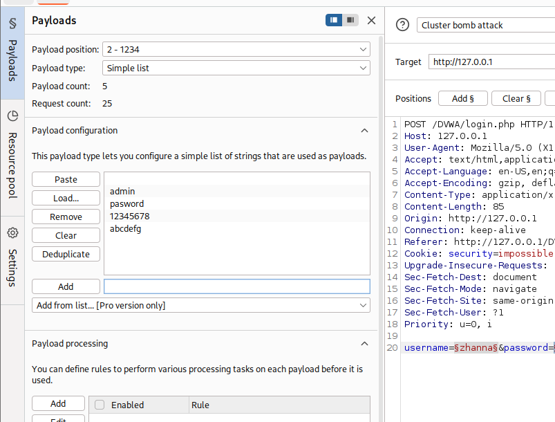

Рисунок 16: Второй список со значениями

Нажимаю start attack, и начинается подбор.

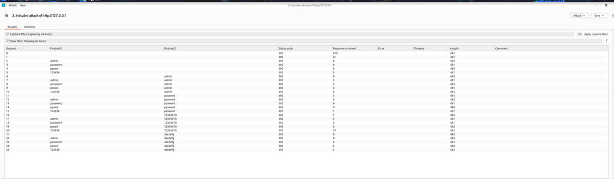

Рисунок 17: Запуск атаки

При открытии результата каждого post-запроса можем увидеть полученный get-запрос: по нему видно, куда нас перенаправило после выполнения ввода пары пользователь-пароль. Например, в случае с подбором пары password-abcdefg нас перенаправило на login.php, это значит, что пара не подходит.

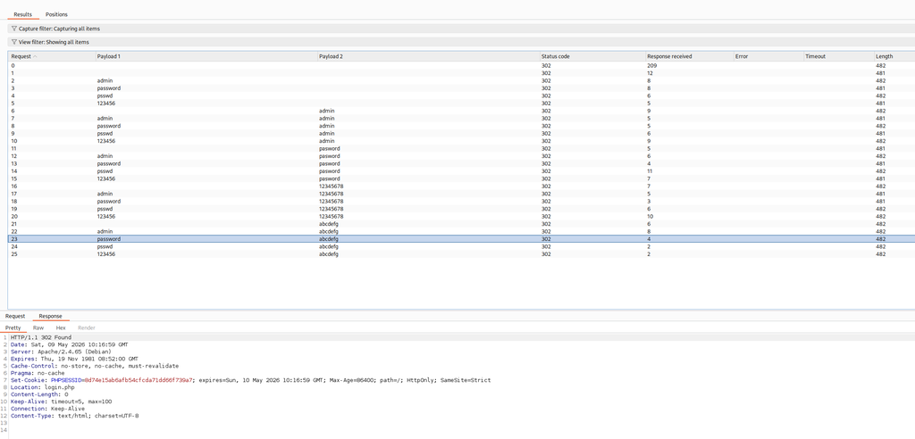

Рисунок 18: Результаты подбора

Проверяем результат пары admin-password во вкладке Response; здесь нас перенаправило на страницу index.php, значит, эта пара верна.

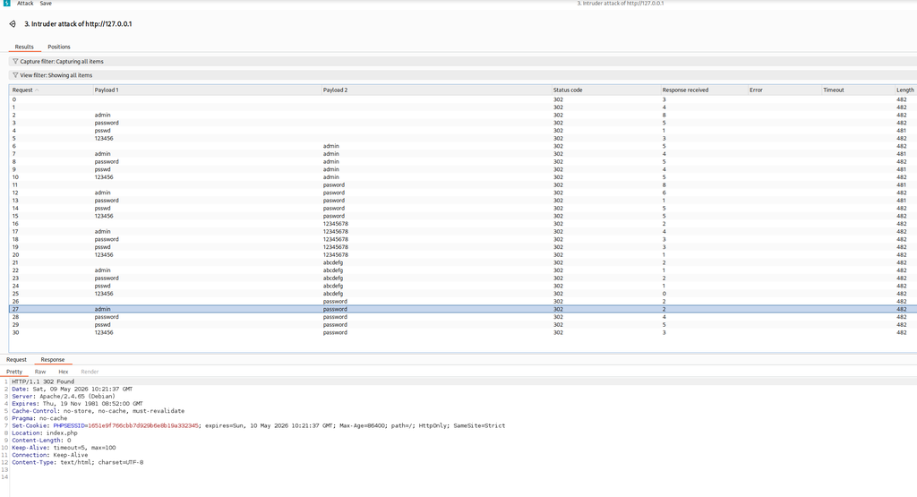

Рисунок 19: Правильно подобранная пара

Если хотим дополнительно проверить с помощью Repeater, нажимаем правой кнопкой мыши на интересующий нас запрос и выбираем “Send to Repeater”.

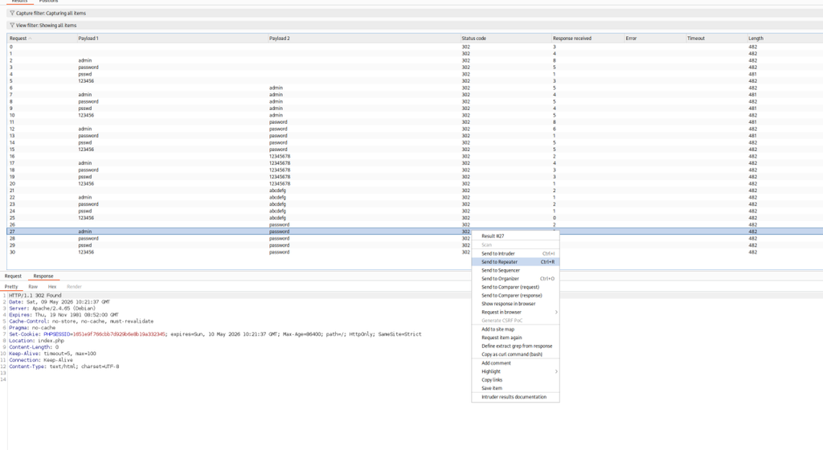

Рисунок 20: Проверка через Repeater

Перехожу во вкладку “Repeater”.

[figure not shown]

Рисунок 21: Вкладка Repeater

Нажав кнопку “send”, получаю в “Response” в строке Location перенаправление на index.php.

[figure not shown]

Рисунок 22: Просмотр Response

Нажав на `Follow redirection`, получаю нескомпилироанный html-код в окне Response.

[figure not shown]

Рисунок 23: html код

Захожу в окно Render и вижу изображение полученной страницы.

[figure not shown]

Рисунок 24: Как выглядит полученная страница в Render

# Результаты

При выполнении данной работы я научилась использовать инструмент Burp Suite.